# Time series analysis project

Random Walk is than considered.

As previously seen this TS has a decreasing trend component due (probably) by covid effect on last month of training set (and also on validation). Random walk is a substitute to this decreasing trend component. Focus plots for first week show a sovraestimation of values in first part of validation, but in the final part prevision are almost equal to true TS values. MAE is 0.4814821.

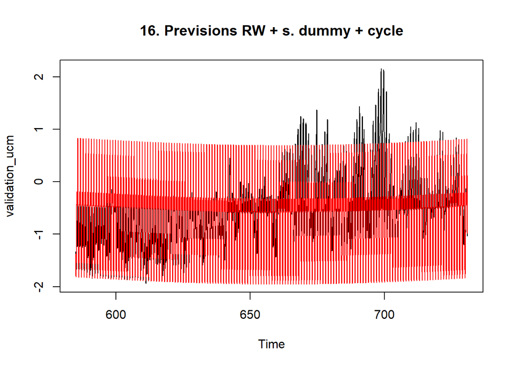

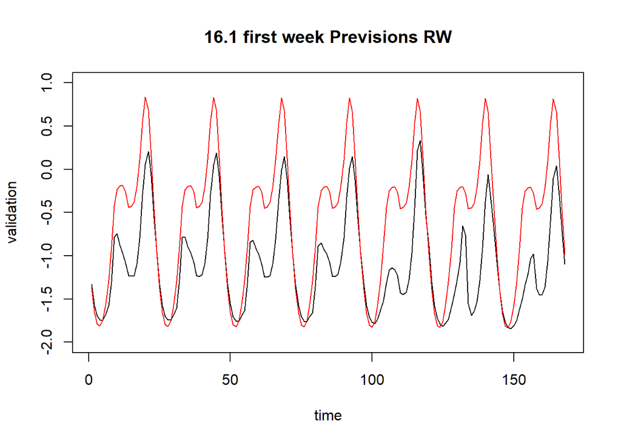

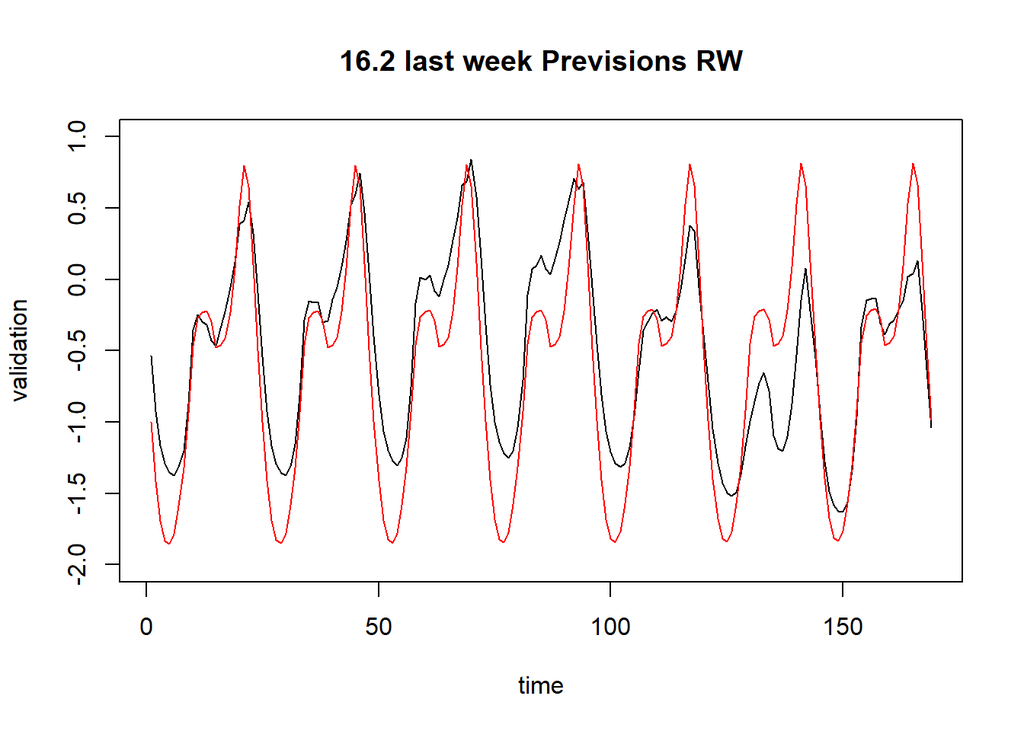

RW model is chosen as best model since its MAE on validation is the lowest of all UCM models trained.

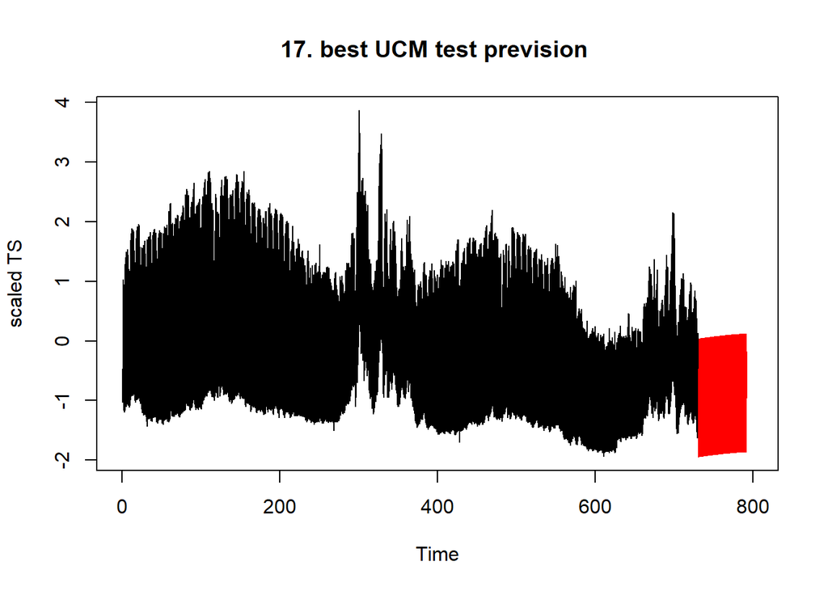

## ML models

### KNN

Training and validation set for KNN models are created respectively using 80% - 20% of data. Models are trined and evaluated on scaled data.

2 type of KNN model are trained using first a week as lenght of TS of which we need to find k Neighbour, and in the second model using a day.

K parameter for first model (number of closest neighbour) is select in range 1-15, for second model the range is larger 1-20 (since lenght of p is smaller). Parameter tuning for k is made trought a cyclic function. Horizon parameter is fixed to validation lenght. Multiple-Step Ahead Strategy used is recursive for both model and the combination function used to aggregate the targets associated with the nearest neighbors is the mean.

```r
train_knn <- ts_stand[1:as.integer(nrow(ts)*0.8)]
validation_knn <-ts_stand[(1+as.integer(nrow(ts)*0.8)) : nrow(ts)]

#-- Parameter
#-- p is the lenght of TS of which we need to find k  Neighbour
p <- 1:(24*7)
p1 <- 1:24

#-- k (Iperparameter k-nn)
k <- seq(1, 15, 2)
k2 <-seq(1, 20, 2)

#-- horzion of forecasat
h <- 3504
```

For model 1 with P=1 week, optimal number of NN is 9 with a corresponding MAE of 0.4345685.

For model 2 with P=1 day, optimal number of NN is 15 with a corresponding MAE of 0.4223891.

```
## [1] 1
## [1] 0.4876315
## [1] 3
## [1] 0.4640554
## [1] 5
## [1] 0.4596265
## [1] 7
## [1] 0.4566622
## [1] 9
## [1] 0.4345685
## [1] 11
## [1] 0.4378493
## [1] 13
## [1] 0.4663213
## [1] 15
## [1] 0.5619335
```

```
## [1] 1
## [1] 0.5125562
## [1] 3
## [1] 0.4921412
## [1] 5
## [1] 0.4799198
## [1] 7
## [1] 0.4367728
## [1] 9
## [1] 0.4328544
## [1] 11
## [1] 0.432866
## [1] 13
## [1] 0.424816
## [1] 15
## [1] 0.4223891
## [1] 17
## [1] 0.4233002
## [1] 19
## [1] 0.4784703
```

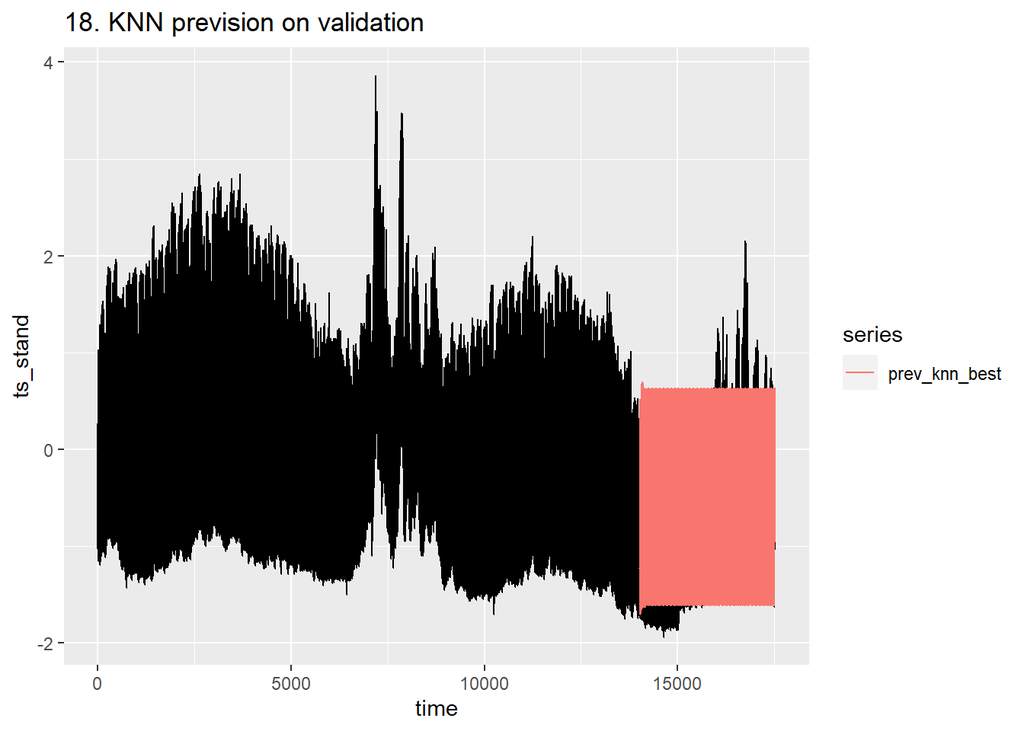

### LSTM

Tensor Format:

Predictors (X) must be a 3D Array with dimensions: [samples, timesteps, features]: The first dimension is the length of values, the second is the number of time steps (lags), and the third is the number of predictors (1 if univariate or n if multivariate) Outcomes/Targets (y) must be a 2D Array with dimensions: [samples, timesteps]: The first dimension is the length of values and the second is the number of time steps (lags)

The training and testing length must be evenly divisible (e.g. training length / testing length must be a whole number)

Batch Size: 73

The batch size is the number of training examples in one forward/backward pass of a RNN before a weight update The batch size must be evenly divisible into both the training an testing lengths (e.g. training length / batch size and testing length / batch size must both be whole numbers)

Time Steps: 24*7

A time step is the number of lags included in the training/testing set

Epochs: 10

The epochs are the total number of forward/backward pass iterations Typically more improves model performance unless overfitting occurs at which time the validation accuracy/loss will not improve.

```r
datalags   <- 24*7 #-- Orizzonte di ricerca
batch.size <- 73 #-- prima era 146
epochs     <- 10


train_lstm <- as.data.frame(ts_stand[seq(16352 + datalags)])
validation_lstm <- as.data.frame(ts_stand[16352 + datalags + seq(1168 + datalags)])

df_val <- ts_stand[(17520-1167) : 17520,] #-- estrarre per mae

colnames(train_lstm) <- c("Valore")
colnames(validation_lstm) <- c("Valore")


x.train <- array(data = lag(train_lstm$Valore, datalags)[ -(1 : datalags)],
                 dim = c(nrow(train_lstm) - datalags, datalags, 1))

y.train <- array(data = train_lstm$Valore[-(1:datalags)],
                 dim = c(nrow(train_lstm)-datalags, 1))

x.test <- array(data = lag(validation_lstm$Valore,
                           datalags)[ -(1 : datalags)],
                dim = c(nrow(validation_lstm) - datalags, datalags, 1))

y.test <- array(data = validation_lstm$Valore[ -(1 : datalags)],
                dim = c(nrow(validation_lstm) - datalags, 1))
```

Long Short-Term Memory A simple LSTM RNN is trained. The model is composed of 2 layer:

- lstm layer with 16 neuron units
- final dense layer

```
## Model
## Model: "sequential"
## ________________________________________________________________________________
## Layer (type)                        Output Shape                    Param #
## ================================================================================
## lstm (LSTM)                         (73, 168, 16)                   1152
## ________________________________________________________________________________
## dense (Dense)                       (73, 168, 1)                    17
## ================================================================================
## Total params: 1,169
## Trainable params: 1,169
## Non-trainable params: 0
## ________________________________________________________________________________
```

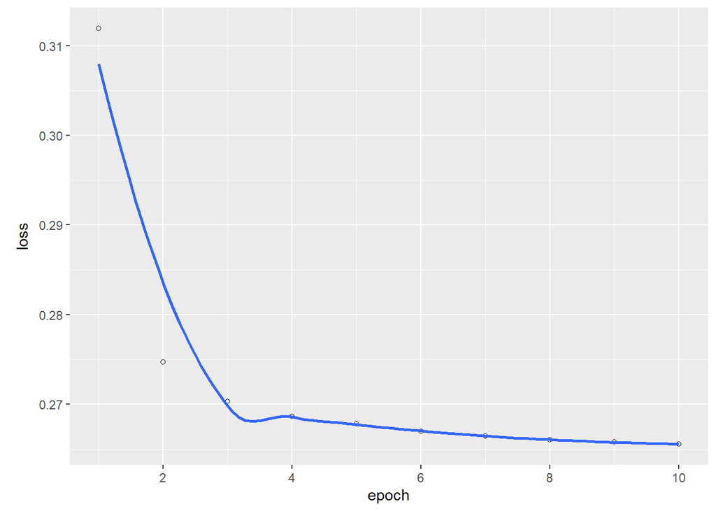

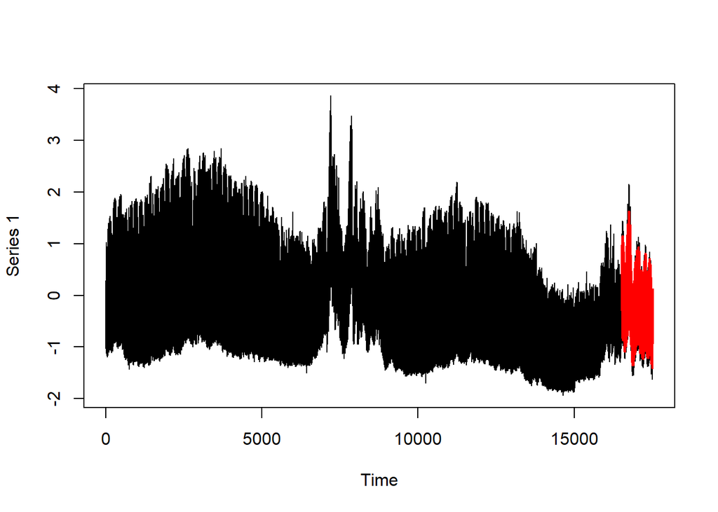

Another LSTM model is trained.

```
## Model
## Model: "sequential_1"
## ________________________________________________________________________________
## Layer (type)                        Output Shape                    Param #
## ================================================================================
## lstm_1 (LSTM)                       (73, 168, 16)                   1152
## ________________________________________________________________________________
## dropout (Dropout)                   (73, 168, 16)                   0
## ________________________________________________________________________________
## lstm_2 (LSTM)                       (73, 8)                         800
## ________________________________________________________________________________
## dropout_1 (Dropout)                 (73, 8)                         0
## ________________________________________________________________________________
## dense_1 (Dense)                     (73, 1)                         9
## ================================================================================
## Total params: 1,961
## Trainable params: 1,961
## Non-trainable params: 0
## ________________________________________________________________________________
```

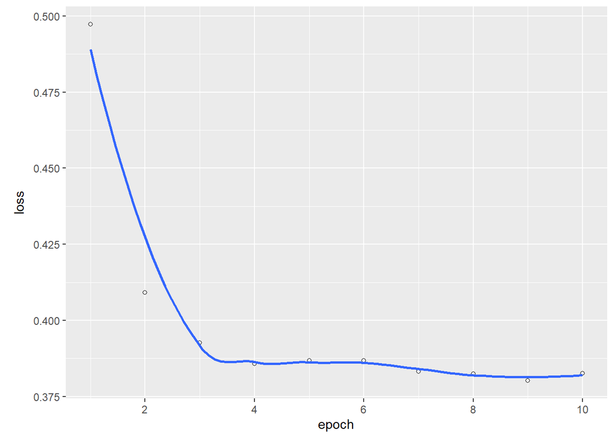

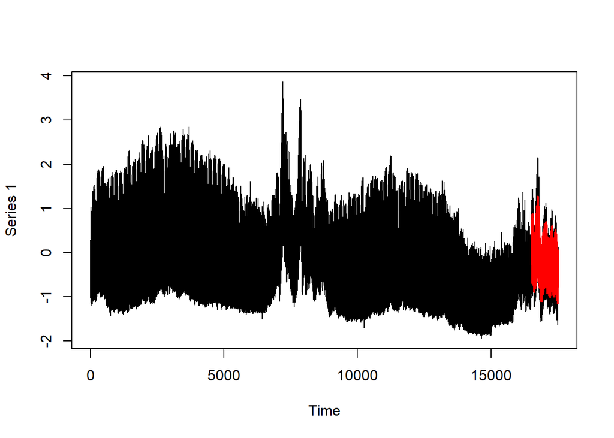

```
## Model
## Model: "sequential_2"
## ________________________________________________________________________________
## Layer (type)                        Output Shape                    Param #
## ================================================================================
## gru (GRU)                           (73, 20)                        1320
## ________________________________________________________________________________
## dense_2 (Dense)                     (73, 1)                         21
## ================================================================================
## Total params: 1,341
## Trainable params: 1,341
## Non-trainable params: 0
## ________________________________________________________________________________
```

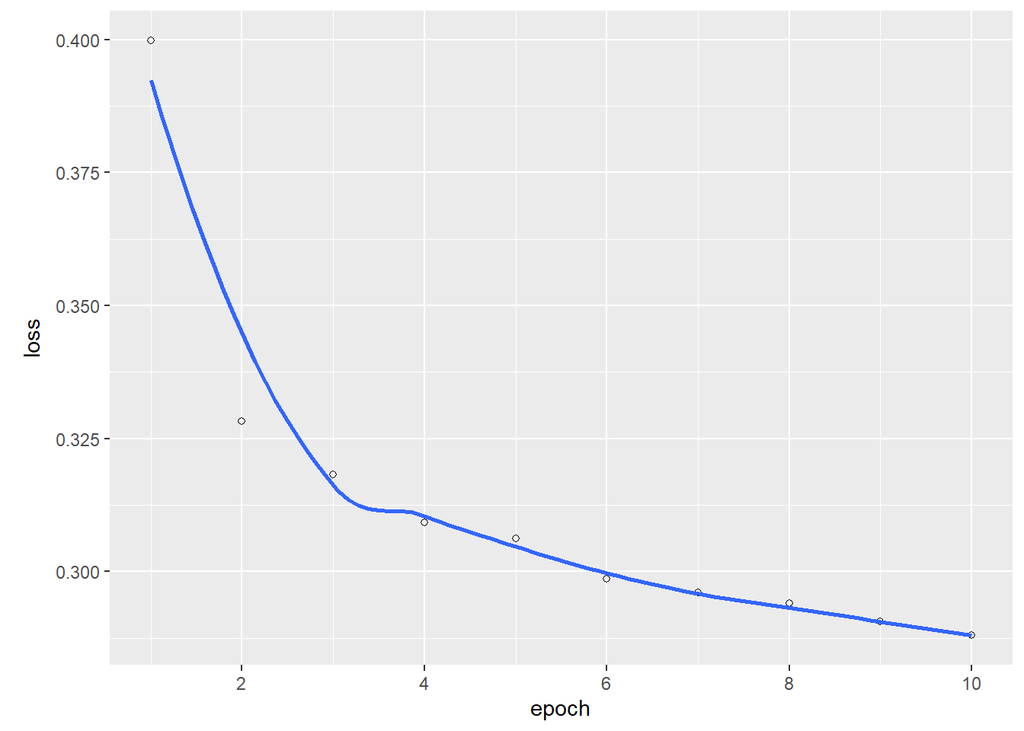

```
##        V1
## 0.4069321
```

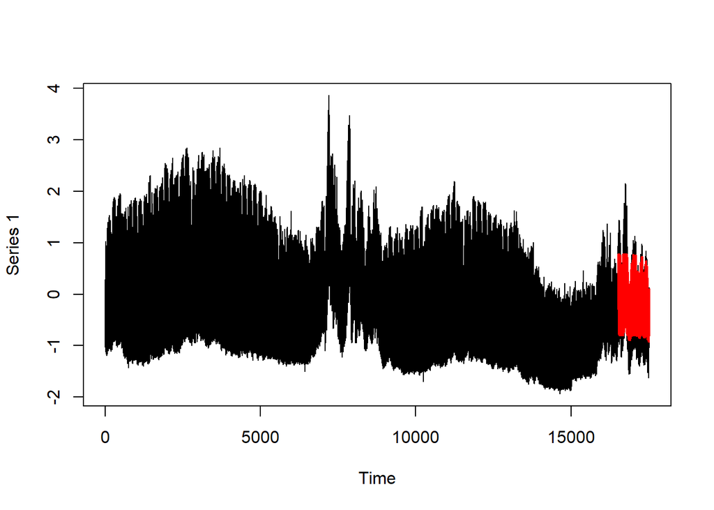

LSTM1 model is chosen to perform prevision on test set. This is consider to be the best model because:

- it is a simple model which obtain good result in terms of mae on valiadtion (0.40) compared to (0.39) of complex model.
- in term of computational time 10 epochs are sufficient to reach a minimum in loss function, for the other 2 model more epochs are needed.

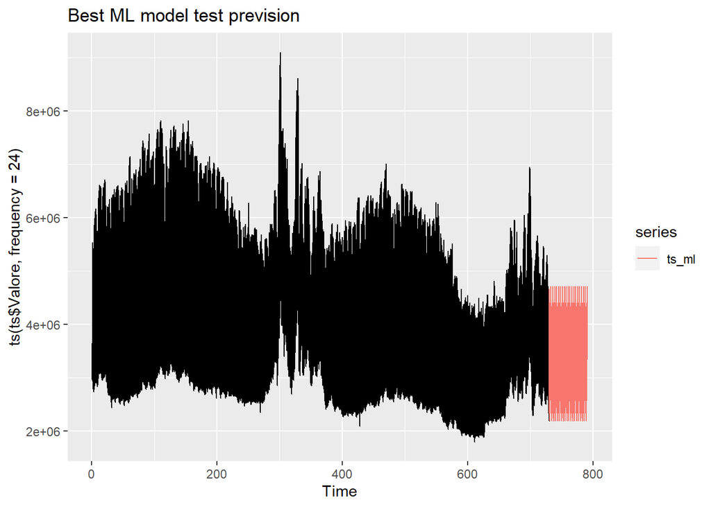

## Conclusion

Best results in term of MAE on validation set are obtained by ML model and Arimax model.

In particular it has been shown that simple arima model and UCM model are affected by the (strong) decreasing trend. In this situation regressors are necessary to model yearly seasonality. UCM models are the worst of all trained model. Probably more complex model should have been trained. Moreover to solve Covid problem a level shift could be added in the models.